# The Impact of Early Proactiveness in the Western Pacific and South-East Asia Regions

Angel Irving

October 20, 2025

# The Arising COVID-19 Pandemic

*Background for Early 2020*

## The Effectiveness of Proactive Measures

*Context of Research*

The Southeast Asia Region and the Western Pacific Region because countries in Asia and Oceania were among the first to respond proactively to COVID-19, shaped by both geographic proximity and their past experiences with outbreaks such as SARS (2002–2003) and MERS (2012). These regions implemented early border closures, strict quarantine systems, and large-scale public health measures that helped curb the spread of the virus during its first months. For instance, Singapore, South Korea, and Vietnam rapidly expanded testing and contact tracing, while Australia and New Zealand introduced border control policies earlier than many Western nations (Siahaan, 2020; Djalante et al., 2020). By examining the reported case numbers from February to March 2020, my research aims to highlight the effectiveness of these early interventions and compare the two regions.

# COVID-19 Data of Early 2020

*Data Used*

The data set I used comes from the COVID-19 Data Repository by the Center for Systems Science and Engineering (CSSE) at Johns Hopkins University. It compiles daily case reports from national health ministries, the World Health Organization, and other verified sources, beginning on January 22, 2020. The data set is structured with rows representing countries/regions and columns representing cumulative case counts for each date.

## Visualizing Data

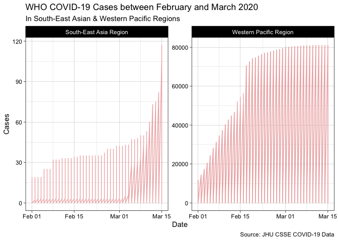

Between February 1 and March 15, 2020, the Western Pacific region recorded a steep rise in COVID-19 cases, reaching a little over 80,000 confirmed infections, while Southeast Asia reported fewer than 120.

```r
#Figure 1 - Comparing Regions

ggplot(WHO_C19.0203_WPSEA, aes(x= Date, y= Cases))+
         geom_line(colour="rosybrown2")+
         facet_wrap(~`WHO region`, scales = "free_y")+
  labs(title= "WHO COVID-19 Cases between February and March 2020", subtitle = "In South-East Asian & Western Pacific Regions", caption = "Source: JHU CSSE COVID-19 Data" )+
  theme_linedraw()
```

- **The Western Pacific’s surge was driven primarily by China’s early outbreak and South Korea’s Daegu cluster, which contributed thousands of cases within days. In contrast, Southeast Asia, despite geographic proximity to Wuhan, reported strikingly low case counts.**

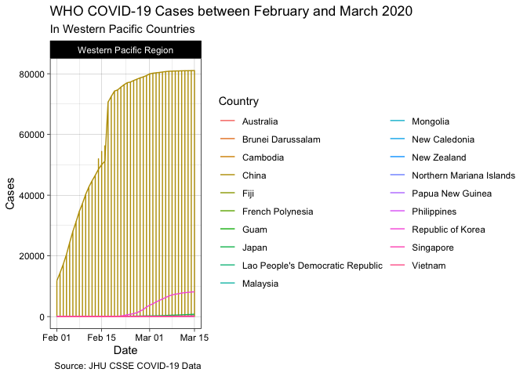

China has the highest number of reported cases as it reached 80,000 cases, South Korea has a slight surge towards March, and other countires like Japan and Singapore had only few hundred cases.

```r
#Figure 2 - Comparing Countries in Western Pacific Region

ggplot(WHO_C19_WP, aes(x= Date, y= Cases))+
         geom_line(aes(colour=`Country/Region`))+
         facet_wrap(~`WHO region`)+
   guides(color = guide_legend(ncol = 2))+
  labs(title= "WHO COVID-19 Cases between February and March 2020", subtitle = "In Western Pacific Countries", colour="Country", caption = "Source: JHU CSSE COVID-19 Data" )+
  theme_linedraw()
```

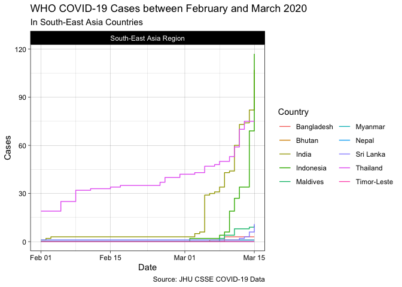

Most South East countries in Asia generally didn’t reach 100 cases except Indonesia with a high of 117 cases.

```r
#Figure 3 - Comparing Countries in South-East Asia Region

ggplot(WHO_C19_SEA, aes(x= Date, y= Cases))+
         geom_step(aes(colour=`Country/Region`))+
         facet_wrap(~`WHO region`)+
   guides(color = guide_legend(ncol = 2))+
  labs(title= "WHO COVID-19 Cases between February and March 2020", subtitle = "In South-East Asia Countries", colour="Country",caption = "Source: JHU CSSE COVID-19 Data" )+
  theme_linedraw()
```

# Differences in Data

In Figure 1., this is a stark difference in reported cases from each region. This gap between the regions reflects both epidemiological and policy differences. Some Western Pacific countries responded rapidly after SARS experience, for example, Vietnam closed borders with China in January, Singapore initiated aggressive airport screening. This difference can be seen in the reported data in Figure 2. In “Most Read of 2020: Southeast Asia’s Responses to the COVID-19 Pandemic,” stronger technical capacity in some states contrasted with delayed detection in others. The ASEAN case study “Status Quo of outbreak and control of COVID-19…” also confirms that lower early case counts were consistent with slower doubling rates, higher recovery ratios, and differences in active case trends across countries. While Western Pacific data reflects the epicenter of global spread, Southeast Asia’s low numbers illustrate how geography alone does not determine the spread, preparedness, policy, and detection capacity play a central role.

# *Sources*

[COVID-19 Data Repository by the Center for Systems Science and Engineering (CSSE) at Johns Hopkins University](https://github.com/CSSEGISandData/COVID-19%22)

[“Putting East Asia and the Pacific on a Path to Recovery from the COVID-19 Crisis .” World Bank, World Bank Group, 7 Dec.2023](https://www.worldbank.org/en/results/2023/12/08/putting-east-asia-and-the-pacific-on-a-path-to-recovery-from-the-covid-19-crisis)

[Siahaan, Gabriele Natalia. “Most Read of 2020: Southeast Asia’s Responses to the COVID-19 Pandemic.” Australian Institute of International Affairs, 5 Jan.2021](https://www.internationalaffairs.org.au/australianoutlook/southeast-asias-responses-to-the-covid-19-pandemic/)

[Hamid, Malai Zeiti Binti Sheikh Abdul, et al. “Status Quo of Outbreak and Control of Covid-19 in Southeast Asian Nations during the First Phase: A Case Study for Sustainable Cities and Communities.” COVID-19 and the Sustainable Development Goals, U.S. National Library of Medicine, 29 July 2022](https://pmc.ncbi.nlm.nih.gov/articles/PMC9335018/)

[Djalante, Riyanti, et al. “Review and Analysis of Current Responses to Covid-19 in Indonesia: Period of January to March 2020.” Progress in Disaster Science, U.S. National Library of Medicine, 4 Apr. 2020](https://pmc.ncbi.nlm.nih.gov/articles/PMC7149002/)